# Taller 4: Generación de Paleta de Colores a partir de Imágenes con Machine Learning No Supervisado

## MINE 4206 - Analisis con Machine Learning (AML) - 2026-10

**Contexto del problema:** Una paleta de colores es un conjunto de tonos que se utilizan juntos para crear un efecto armonioso, coherente y atractivo en representaciones visuales (diseño gráfico, cine, fotografía, pintura). En un contexto de amplia demanda de herramientas para asistir a diseñadores gráficos, directores de arte y creadores de contenido en la selección de colores, una aplicación capaz de extraer paletas automáticamente a partir de imágenes resulta de gran utilidad.

**Objetivo:** Desarrollar un método basado en técnicas de agrupación (machine learning no supervisado) que permita extraer los tonos dominantes de una imagen y generar un muestrario representativo de los colores presentes. El método debe adaptarse a las características de cada imagen, ajustando automáticamente el número de colores de la paleta (máximo siete).

**Enfoque general del método:**

1. **Preparación de las imágenes:** redimensionado y conversión al espacio de color CIE Lab.
2. **Agrupación de píxeles:** algoritmo K-Means con selección automática de K mediante un enfoque híbrido que combina el coeficiente de silueta y el método del codo sobre la inercia.
3. **Generación de la paleta:** transformación de los centroides de los grupos en un muestrario representativo, ordenado por frecuencia.
4. **Visualización:** proyección de los píxeles a un espacio 2D mediante t-SNE, coloreando cada punto con su color real para validar la calidad de la agrupación.

## 0. Importación de Librerías

```python
# Instalación de librerías
!pip install numpy pandas matplotlib seaborn scikit-learn scikit-image Pillow kneed
```

```
  Obtaining dependency information for kneed from https://files.pythonhosted.org/packages/4a/cd/23c89d53c36028bccb39f55aa5dd24c4bdaab76c4d556ad43dc8cf026918/kneed-0.8.6-py3-none-any.whl.metadata
Downloading kneed-0.8.6-py3-none-any.whl (10 kB)
```

```python
# Librerías básicas
import os
import numpy as np
import pandas as pd
import matplotlib.pyplot as plt
import matplotlib.patches as patches
from matplotlib.gridspec import GridSpec
import seaborn as sns

# Procesamiento de imágenes
from PIL import Image
from skimage import color

# Clustering y métricas
from sklearn.cluster import KMeans
from sklearn.metrics import silhouette_score, davies_bouldin_score, calinski_harabasz_score

# Reducción de dimensionalidad
from sklearn.manifold import TSNE

# Detección automática del codo
from kneed import KneeLocator

# Configuración de visualización
plt.style.use('seaborn-v0_8-whitegrid')
pd.set_option('display.max_columns', None)
import warnings
warnings.filterwarnings('ignore')

# Semilla global para reproducibilidad
SEED = 42
np.random.seed(SEED)

print("Librerías cargadas correctamente.")
```

```
Librerías cargadas correctamente.
```

## 1. Recopilación de Imágenes

En esta sección se presenta el conjunto de imágenes seleccionadas para el desarrollo del método. Las obras fueron descargadas del repositorio [WikiArt](https://www.wikiart.org/), referenciado en el enunciado del taller (también disponible en el [dataset de Kaggle WikiArt](https://www.kaggle.com/datasets/steubk/wikiart)).

### 1.1 Criterios de selección

Se seleccionaron **8 obras** de **4 artistas** que representan **4 estilos artísticos claramente diferenciados**, con el fin de poner a prueba el método sobre paletas cromáticas contrastantes:

| Artista | Estilo | Característica cromática |
| --- | --- | --- |
| **Aldemir Martins** (Brasil) | Figurativo brasileño moderno | Colores primarios planos y saturados |
| **Andrea del Sarto** (Italia) | Renacimiento italiano (s. XVI) | Tonos terrosos, ocres y rojizos profundos |
| **Chuck Close** (EE.UU.) | Fotorrealismo / mosaico contemporáneo | Multitud de microcolores en estructura modular |
| **A.Y. Jackson** (Canadá) | Grupo de los Siete / paisajismo | Tonos naturales contrastantes (nieve, montaña, vegetación) |

**Motivación de la selección:**

- **Diversidad cromática:** las obras cubren un rango amplio de paletas, desde primarios saturados (Martins) hasta tonos cálidos terrosos (del Sarto) y composiciones complejas multicolor (Close).
- **Diversidad estilística:** se incluyen estilos de distintas épocas (siglo XVI a contemporáneo), regiones (Europa, América Latina, Norteamérica) y técnicas (pintura clásica, ilustración pop, mosaico fotorrealista).
- **Validación del método:** la diferencia entre las obras permite evidenciar que el número óptimo de colores (K) debe ajustarse a las características de cada imagen, como exige el enunciado.

### 1.2 Carga y visualización del conjunto de imágenes

```python
# Ruta a la carpeta de imágenes (ruta relativa al notebook)
RUTA_IMAGENES = './imagenes'

# Listar archivos de imagen disponibles
archivos_imagenes = sorted([f for f in os.listdir(RUTA_IMAGENES) if f.lower().endswith(('.jpg', '.jpeg', '.png'))])

print(f"Total de imágenes encontradas: {len(archivos_imagenes)}")
print(f"\nArchivos:")
for i, archivo in enumerate(archivos_imagenes, 1):
    print(f"  {i}. {archivo}")
```

```
Total de imágenes encontradas: 8

Archivos:
  1. a.y.-jackson_hills-at-great-bear-lake-1953.jpg
  2. a.y.-jackson_valley-of-the-gouffre-river-1933.jpg
  3. aldemir-martins_baiana-1980.jpg
  4. aldemir-martins_blue-cat.jpg
  5. andrea-del-sarto_charity.jpg
  6. andrea-del-sarto_christ-the-redeemer.jpg
  7. chuck-close_agnes-1998.jpg
  8. chuck-close_john-1998.jpg
```

[figure not shown]

```python
# Función auxiliar para extraer artista y título a partir del nombre de archivo
# Mapeo manual para nombres complejos (apellidos compuestos, abreviaturas)
NOMBRES_ARTISTAS = {
    'a_y_-jackson': 'A.Y. Jackson',
    'aldemir-martins': 'Aldemir Martins',
    'andrea-del-sarto': 'Andrea del Sarto',
    'chuck-close': 'Chuck Close',
}

def parsear_nombre(archivo):
    """Extrae el artista y el título de la obra a partir del nombre del archivo."""
    nombre = os.path.splitext(archivo)[0]
    # Separar por el primer '_' que viene después del nombre del artista
    for clave, artista_legible in NOMBRES_ARTISTAS.items():
        if nombre.startswith(clave + '_'):
            titulo_raw = nombre[len(clave)+1:]
            titulo = titulo_raw.replace('-', ' ').title()
            # Limpiar paréntesis de años, "1980" → "(1980)"
            partes = titulo.rsplit(' ', 1)
            if len(partes) == 2 and partes[1].isdigit() and len(partes[1]) == 4:
                titulo = f"{partes[0]} ({partes[1]})"
            return artista_legible, titulo
    # Fallback genérico
    partes = nombre.split('_', 1)
    artista = partes[0].replace('-', ' ').title()
    titulo = partes[1].replace('-', ' ').replace('_', ' ').title() if len(partes) > 1 else ''
    return artista, titulo

# Visualización del conjunto de imágenes seleccionadas
fig, axes = plt.subplots(2, 4, figsize=(18, 10))
axes = axes.flatten()

for i, archivo in enumerate(archivos_imagenes):
    img = Image.open(os.path.join(RUTA_IMAGENES, archivo)).convert('RGB')
    artista, titulo = parsear_nombre(archivo)
    axes[i].imshow(img)
    axes[i].set_title(f"{artista}\n{titulo}", fontsize=10)
    axes[i].axis('off')

plt.suptitle('Conjunto de obras seleccionadas para el taller', fontsize=14, fontweight='bold')
plt.tight_layout()
plt.show()
```

## 2. Preparación de las Imágenes

En esta sección se construye el **pipeline de preparación** que transforma cada imagen en una matriz de píxeles lista para la etapa de agrupación. Antes de implementarlo se justifican las decisiones tomadas.

### 2.1 Justificación de las transformaciones

**Decisión 1: Redimensionar a 200 × 200 píxeles.**

Una imagen típica de WikiArt puede tener entre 1 y 6 millones de píxeles. Agrupar esa cantidad con K-Means es innecesariamente costoso y no aporta información adicional sobre los colores dominantes: la distribución cromática global ya queda bien representada con un muestreo regular. Redimensionar a 200×200 nos deja con **40 000 píxeles por imagen**, suficiente para capturar la riqueza de colores y rápido de procesar. Se utiliza el filtro `LANCZOS` que preserva mejor la información cromática que `NEAREST` o `BILINEAR` al reducir.

**Decisión 2: Convertir del espacio RGB al espacio CIE Lab.**

El espacio RGB es el formato nativo de las imágenes, pero **no es perceptualmente uniforme**: dos colores con la misma distancia euclidiana en RGB no necesariamente se perciben como igual de diferentes para el ojo humano. Como K-Means utiliza la distancia euclidiana para asignar píxeles a grupos (según vimos en la S10 del curso), trabajar en RGB puede producir agrupaciones que no se correspondan con la similitud visual real.

El espacio **CIE Lab** fue diseñado precisamente para que las distancias euclidianas aproximen las diferencias perceptuales. Está compuesto por:

- **L**: luminosidad (0 = negro, 100 = blanco)
- **a**: eje verde (-) ↔ rojo (+)
- **b**: eje azul (-) ↔ amarillo (+)

Trabajar en Lab garantiza que los grupos formados por K-Means correspondan a tonos visualmente similares para el ojo humano, lo cual es el objetivo natural de una paleta de colores.

**Decisión 3: No aplicar escalado adicional.**

El material del curso (S10) recomienda escalado para K-Means cuando los atributos tienen unidades o rangos muy distintos. En el espacio Lab los tres canales ya están en escalas comparables (L en [0,100], a y b típicamente en [-128, 127]). Aplicar StandardScaler distorsionaría las distancias perceptuales que justamente queremos preservar.

**Decisión 4: No filtrar píxeles atípicos.**

No se eliminan píxeles "extremos" (bordes, marcos, esquinas) porque en obras de arte estos píxeles **forman parte de la composición** y deben contribuir a la paleta. Si la obra tiene un marco oscuro, ese tono pertenece legítimamente al muestrario.

### 2.2 Construcción del pipeline de preparación

```python
def preparar_imagen(ruta, tamano_objetivo=200):
    """
    Pipeline de preparación de una imagen.

    Pasos:
    1. Carga y conversión a RGB (descarta canal alpha si existe).
    2. Redimensionado a tamano_objetivo × tamano_objetivo con filtro Lanczos.
    3. Normalización a [0, 1].
    4. Conversión al espacio de color CIE Lab.
    5. Aplanado a matriz de píxeles (N × 3).

    Parámetros
    ----------
    ruta : str
        Ruta absoluta o relativa al archivo de imagen.
    tamano_objetivo : int
        Lado de la imagen redimensionada (default 200).

    Retorna
    -------
    img_pil : PIL.Image
        Imagen redimensionada (para visualización).
    pixels_rgb : np.ndarray
        Matriz de píxeles en RGB normalizado, shape (N, 3).
    pixels_lab : np.ndarray
        Matriz de píxeles en CIE Lab, shape (N, 3).
    """
    # 1-2. Carga y redimensionado
    img_pil = Image.open(ruta).convert('RGB')
    img_pil = img_pil.resize((tamano_objetivo, tamano_objetivo), Image.LANCZOS)

    # 3. Normalización a [0, 1] (necesaria para skimage.color.rgb2lab)
    arr_rgb = np.array(img_pil) / 255.0

    # 4. Conversión a Lab
    arr_lab = color.rgb2lab(arr_rgb)

    # 5. Aplanado a (N, 3)
    pixels_rgb = arr_rgb.reshape(-1, 3)
    pixels_lab = arr_lab.reshape(-1, 3)

    return img_pil, pixels_rgb, pixels_lab

print("Pipeline de preparación definido.")
```

```
Pipeline de preparación definido.
```

### 2.3 Validación del pipeline sobre una imagen de muestra

```python
# Aplicar pipeline sobre la primera imagen y revisar resultados
ruta_muestra = os.path.join(RUTA_IMAGENES, archivos_imagenes[0])
img_muestra, pixels_rgb_muestra, pixels_lab_muestra = preparar_imagen(ruta_muestra)

print("=== Validación del pipeline ===")
print(f"\nImagen procesada: {archivos_imagenes[0]}")
print(f"Dimensiones imagen redimensionada: {img_muestra.size}")
print(f"Forma de pixels_rgb: {pixels_rgb_muestra.shape}")
print(f"Forma de pixels_lab: {pixels_lab_muestra.shape}")
print(f"\nRango de valores RGB normalizado:")
print(f"  R: [{pixels_rgb_muestra[:,0].min():.3f}, {pixels_rgb_muestra[:,0].max():.3f}]")
print(f"  G: [{pixels_rgb_muestra[:,1].min():.3f}, {pixels_rgb_muestra[:,1].max():.3f}]")
print(f"  B: [{pixels_rgb_muestra[:,2].min():.3f}, {pixels_rgb_muestra[:,2].max():.3f}]")
print(f"\nRango de valores Lab:")
print(f"  L: [{pixels_lab_muestra[:,0].min():.2f}, {pixels_lab_muestra[:,0].max():.2f}]")
print(f"  a: [{pixels_lab_muestra[:,1].min():.2f}, {pixels_lab_muestra[:,1].max():.2f}]")
print(f"  b: [{pixels_lab_muestra[:,2].min():.2f}, {pixels_lab_muestra[:,2].max():.2f}]")
```

```
=== Validación del pipeline ===

Imagen procesada: a.y.-jackson_hills-at-great-bear-lake-1953.jpg
Dimensiones imagen redimensionada: (200, 200)
Forma de pixels_rgb: (40000, 3)
Forma de pixels_lab: (40000, 3)

Rango de valores RGB normalizado:
  R: [0.106, 0.945]
  G: [0.122, 0.886]
  B: [0.110, 0.596]

Rango de valores Lab:
  L: [11.78, 87.99]
  a: [-20.89, 51.31]
  b: [-7.99, 62.30]
```

[figure not shown]

```python
# Visualizar la imagen muestra y la distribución de sus píxeles en los canales Lab
fig, axes = plt.subplots(1, 4, figsize=(20, 4))

axes[0].imshow(img_muestra)
axes[0].set_title('Imagen redimensionada (200×200)')
axes[0].axis('off')

axes[1].hist(pixels_lab_muestra[:, 0], bins=50, color='gray', edgecolor='black')
axes[1].set_title('Distribución del canal L (luminosidad)')
axes[1].set_xlabel('L')
axes[1].set_ylabel('Frecuencia')

axes[2].hist(pixels_lab_muestra[:, 1], bins=50, color='salmon', edgecolor='black')
axes[2].set_title('Distribución del canal a (verde ↔ rojo)')
axes[2].set_xlabel('a')
axes[2].set_ylabel('Frecuencia')

axes[3].hist(pixels_lab_muestra[:, 2], bins=50, color='gold', edgecolor='black')
axes[3].set_title('Distribución del canal b (azul ↔ amarillo)')
axes[3].set_xlabel('b')
axes[3].set_ylabel('Frecuencia')

plt.tight_layout()
plt.show()
```

## 3. Desarrollo del Modelo de Agrupación

Esta sección desarrolla el modelo de agrupación que identifica los colores dominantes de cada imagen. Incluye la justificación de la elección del algoritmo, la estrategia de búsqueda automática del número óptimo de grupos (K) y la validación con métricas de evaluación.

### 3.1 Justificación del algoritmo: K-Means

Se selecciona **K-Means** como algoritmo principal por las siguientes razones, alineadas con el material del curso (S10: *Aprendizaje no supervisado - Agrupación*):

1. **Coherencia pedagógica.** K-Means es el algoritmo central desarrollado en la S10 del curso, incluyendo su formulación matemática, características, ventajas y limitaciones.
2. **Naturaleza de los datos.** Los píxeles en el espacio Lab son **atributos numéricos en escalas comparables**, condición ideal para K-Means según la S10. Además, no hay atributos categóricos que justifiquen alternativas como K-Modes o K-Prototypes.
3. **Forma esperada de los grupos.** Los colores dominantes de una imagen tienden a formar **regiones aproximadamente convexas** en el espacio Lab (un cluster de "azules" se distribuye alrededor de un centroide). Esta es exactamente la situación en que K-Means desempeña bien, según lo expuesto en clase.
4. **Interpretabilidad del prototipo.** El centroide de cada grupo, al ser la **media de los píxeles en Lab**, es directamente interpretable como "el color representativo" del grupo — exactamente lo que necesitamos para generar la paleta.
5. **Eficiencia computacional.** Con 40 000 píxeles por imagen y barridos de K, la eficiencia de K-Means es preferible a algoritmos jerárquicos (O(n²)) o métodos como Affinity Propagation.
6. **Precedente en el material del curso.** El proyecto SOLAR presentado en la S12 utiliza K-Means precisamente para agrupar píxeles en imágenes solares.

**Limitaciones reconocidas (S10):** K-Means es sensible a la inicialización y requiere especificar K a priori. Para mitigar esto:

- Se utiliza inicialización **k-means++** (default en scikit-learn), que distribuye los centros iniciales de forma estratégica.
- Se ejecutan **10 inicializaciones distintas** (`n_init=10`) y se conserva la mejor.
- El número de grupos K se selecciona **automáticamente** mediante el enfoque descrito en la sección 3.2.

### 3.2 Búsqueda automática del número óptimo de grupos (K)

El enunciado del taller exige que **K se ajuste a las características de cada imagen** y no sea un valor fijo, con un máximo de 7 colores. Se evaluará K en el rango **[2, 7]** usando un enfoque híbrido.

**Métricas evaluadas:**

| Métrica | Tipo | Interpretación | Objetivo |
| --- | --- | --- | --- |
| **Coeficiente de silueta** | Intrínseca, S10 | Combina cohesión interna y separación entre grupos. Rango [-1, 1]. | Maximizar |
| **Inercia (suma de distancias al cuadrado)** | Intrínseca, S10 | Compactación interna de los grupos. | Minimizar (curva del codo) |
| **Davies-Bouldin** | Intrínseca | Razón promedio entre dispersión intra-grupo y separación inter-grupo. | Minimizar |
| **Calinski-Harabasz** | Intrínseca | Razón entre dispersión inter-grupo e intra-grupo. | Maximizar |

**Estrategia de selección híbrida:**

Se observa que el coeficiente de silueta tiende a favorecer **bipartitions simples** (K=2) en imágenes con distribuciones continuas de color, porque la separación claro/oscuro produce el mejor balance cohesión/separación. Sin embargo, **K=2 contradice el objetivo del taller**: una paleta de solo dos colores no captura los tonos dominantes de una pintura.

Por ello se diseña la siguiente regla:

1. Calcular **K_sil** = argmax(silhouette) sobre el rango [2, 7].
2. Detectar el **codo de la curva de inercia** (K_codo) mediante el algoritmo de KneeLocator.
3. **Decisión final:**
   - Si K_sil ≥ K_codo → usar K_sil (silhouette confirma una estructura clara).
   - Si K_sil < K_codo → usar K_codo (silhouette sobre-simplifica; el codo indica que añadir más clusters sigue mejorando la compactación de forma significativa).

Esta regla privilegia el codo cuando hay desacuerdo, porque para el problema de paletas de colores **la representatividad cromática (compactación)** es más importante que la separación máxima entre dos grupos. Davies-Bouldin y Calinski-Harabasz se reportan como validación adicional.

### 3.3 Implementación de la búsqueda de K

```python
def evaluar_k(pixels_lab, rango_k=range(2, 8), seed=SEED, n_muestra_metricas=5000):
    """
    Entrena K-Means para cada K en el rango y calcula múltiples métricas de evaluación.

    Parámetros
    ----------
    pixels_lab : np.ndarray
        Matriz de píxeles en espacio Lab, shape (N, 3).
    rango_k : iterable de int
        Valores de K a evaluar.
    seed : int
        Semilla para reproducibilidad.
    n_muestra_metricas : int
        Tamaño de muestra para calcular silhouette y Davies-Bouldin
        (estas métricas son O(n²) y se hacen lentas con N grande).

    Retorna
    -------
    df_metricas : pd.DataFrame
        Tabla con métricas por valor de K.
    modelos : dict
        Diccionario {k: modelo_KMeans_entrenado}.
    """
    rng = np.random.default_rng(seed)
    if len(pixels_lab) > n_muestra_metricas:
        idx = rng.choice(len(pixels_lab), n_muestra_metricas, replace=False)
        muestra = pixels_lab[idx]
    else:
        muestra = pixels_lab

    resultados = []
    modelos = {}

    for k in rango_k:
        km = KMeans(n_clusters=k, n_init=10, init='k-means++', random_state=seed)
        km.fit(pixels_lab)
        modelos[k] = km

        labels_muestra = km.predict(muestra)
        sil = silhouette_score(muestra, labels_muestra)
        db = davies_bouldin_score(muestra, labels_muestra)
        ch = calinski_harabasz_score(muestra, labels_muestra)

        resultados.append({
            'K': k,
            'Silhouette': sil,
            'Davies-Bouldin': db,
            'Calinski-Harabasz': ch,
            'Inercia': km.inertia_
        })

    df_metricas = pd.DataFrame(resultados)
    return df_metricas, modelos


def seleccionar_k_optimo(df_metricas):
    """
    Aplica la regla híbrida silhouette + codo para seleccionar K óptimo.

    Retorna
    -------
    k_sil : int
        K que maximiza silhouette.
    k_codo : int
        K detectado por el método del codo sobre inercia.
    k_final : int
        K seleccionado según la regla híbrida.
    justificacion : str
        Texto explicando la decisión.
    """
    rango_k = df_metricas['K'].tolist()
    silhouettes = df_metricas['Silhouette'].tolist()
    inercias = df_metricas['Inercia'].tolist()

    k_sil = rango_k[int(np.argmax(silhouettes))]

    # Detección del codo: KneeLocator espera curva convexa decreciente
    kl = KneeLocator(rango_k, inercias, curve='convex', direction='decreasing')
    k_codo = int(kl.knee) if kl.knee is not None else rango_k[len(rango_k) // 2]

    # Regla híbrida
    if k_sil >= k_codo:
        k_final = k_sil
        justificacion = (
            f"K={k_sil} seleccionado por máxima silueta ({max(silhouettes):.3f}); "
            f"coherente con codo en K={k_codo}."
        )
    else:
        k_final = k_codo
        justificacion = (
            f"K={k_codo} seleccionado por método del codo. "
            f"Silueta sugería K={k_sil} pero esto sobre-simplifica la paleta."
        )

    return k_sil, k_codo, k_final, justificacion

print("Funciones de búsqueda de K definidas.")
```

```
Funciones de búsqueda de K definidas.
```

### 3.4 Ejemplo de búsqueda de K sobre una imagen

```python
# Aplicar búsqueda de K a la primera imagen como demostración
ruta_demo = os.path.join(RUTA_IMAGENES, archivos_imagenes[0])
_, _, pixels_lab_demo = preparar_imagen(ruta_demo)

print(f"=== Búsqueda de K para: {archivos_imagenes[0]} ===\n")
df_demo, modelos_demo = evaluar_k(pixels_lab_demo)
print(df_demo.to_string(index=False))

k_sil, k_codo, k_final, justif = seleccionar_k_optimo(df_demo)
print(f"\n--- Decisión ---")
print(f"K_silhouette: {k_sil}")
print(f"K_codo: {k_codo}")
print(f"K_final: {k_final}")
print(f"Justificación: {justif}")
```

```
=== Búsqueda de K para: a.y.-jackson_hills-at-great-bear-lake-1953.jpg ===

 K  Silhouette  Davies-Bouldin  Calinski-Harabasz      Inercia
 2    0.451746        0.802170        5728.309540 8.197461e+06
 3    0.369701        0.998759        5003.154277 5.890173e+06
 4    0.408808        0.812087        5406.036631 4.099539e+06
 5    0.363043        0.913360        5195.715937 3.409123e+06
 6    0.355451        0.914850        4908.466252 2.993597e+06
 7    0.356005        0.928506        4757.492023 2.629516e+06

--- Decisión ---
K_silhouette: 2
K_codo: 4
K_final: 4
Justificación: K=4 seleccionado por método del codo. Silueta sugería K=2 pero esto sobre-simplifica la paleta.
```

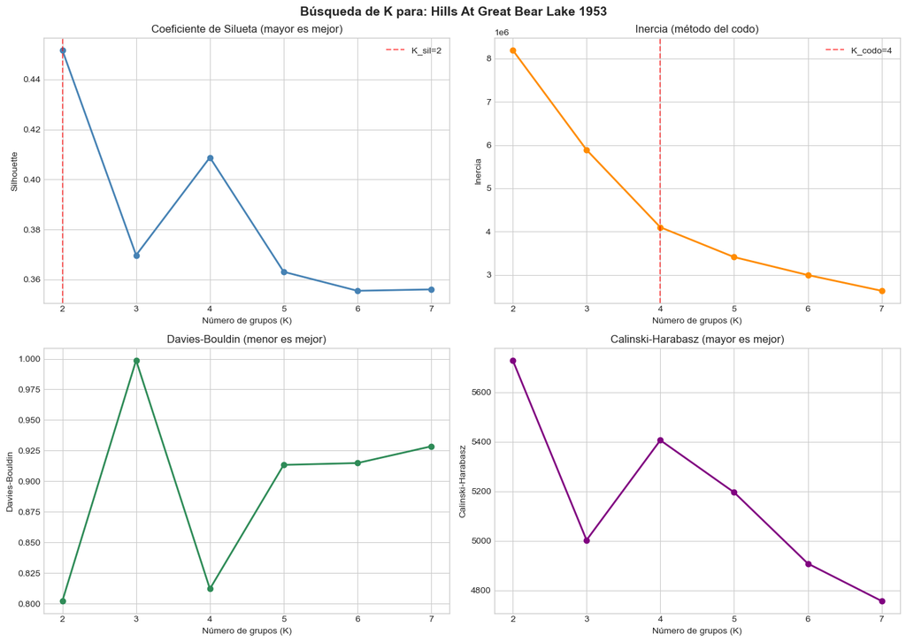

```python
# Visualización de las métricas para la imagen demo
fig, axes = plt.subplots(2, 2, figsize=(14, 10))

axes[0, 0].plot(df_demo['K'], df_demo['Silhouette'], marker='o', linewidth=2, color='steelblue')
axes[0, 0].axvline(k_sil, color='red', linestyle='--', alpha=0.6, label=f'K_sil={k_sil}')
axes[0, 0].set_title('Coeficiente de Silueta (mayor es mejor)')
axes[0, 0].set_xlabel('Número de grupos (K)')
axes[0, 0].set_ylabel('Silhouette')
axes[0, 0].legend()
axes[0, 0].grid(True)

axes[0, 1].plot(df_demo['K'], df_demo['Inercia'], marker='o', linewidth=2, color='darkorange')
axes[0, 1].axvline(k_codo, color='red', linestyle='--', alpha=0.6, label=f'K_codo={k_codo}')
axes[0, 1].set_title('Inercia (método del codo)')
axes[0, 1].set_xlabel('Número de grupos (K)')
axes[0, 1].set_ylabel('Inercia')
axes[0, 1].legend()
axes[0, 1].grid(True)

axes[1, 0].plot(df_demo['K'], df_demo['Davies-Bouldin'], marker='o', linewidth=2, color='seagreen')
axes[1, 0].set_title('Davies-Bouldin (menor es mejor)')
axes[1, 0].set_xlabel('Número de grupos (K)')
axes[1, 0].set_ylabel('Davies-Bouldin')
axes[1, 0].grid(True)

axes[1, 1].plot(df_demo['K'], df_demo['Calinski-Harabasz'], marker='o', linewidth=2, color='purple')
axes[1, 1].set_title('Calinski-Harabasz (mayor es mejor)')
axes[1, 1].set_xlabel('Número de grupos (K)')
axes[1, 1].set_ylabel('Calinski-Harabasz')
axes[1, 1].grid(True)

plt.suptitle(f'Búsqueda de K para: {parsear_nombre(archivos_imagenes[0])[1]}',
             fontsize=14, fontweight='bold')
plt.tight_layout()
plt.show()
```

## 4. Generación del Muestrario de Colores

Esta sección define la función que **transforma los grupos identificados por K-Means en una paleta representativa**. La paleta se ordena por proporción de píxeles asignados a cada grupo (los colores más dominantes aparecen primero).

### 4.1 Estrategia de generación de la paleta

Cada centroide de K-Means en el espacio Lab corresponde al "color promedio" de su grupo. Sin embargo, para visualizar la paleta necesitamos los colores en RGB. La estrategia es:

1. **Calcular el color representativo de cada grupo en RGB**, promediando los valores RGB originales de los píxeles asignados al grupo. Esto es equivalente a transformar el centroide Lab a RGB, pero más robusto numéricamente y conserva fidelidad cromática.
2. **Calcular la proporción** de píxeles asignados a cada grupo (importancia del color en la imagen).
3. **Ordenar la paleta** por proporción descendente (los colores dominantes primero).
4. **Devolver tanto los colores como sus proporciones** para visualizaciones tipo barra proporcional.

### 4.2 Implementación de la función

```python
def generar_paleta(modelo_kmeans, pixels_rgb, labels):
    """
    Transforma los grupos identificados por K-Means en una paleta de colores ordenada.

    Parámetros
    ----------
    modelo_kmeans : sklearn.cluster.KMeans
        Modelo ajustado.
    pixels_rgb : np.ndarray
        Píxeles en RGB normalizado [0, 1], shape (N, 3).
    labels : np.ndarray
        Etiquetas de cluster para cada píxel, shape (N,).

    Retorna
    -------
    paleta_rgb : np.ndarray
        Colores de la paleta en RGB normalizado, ordenados por proporción descendente.
    proporciones : np.ndarray
        Proporción de píxeles asignados a cada color de la paleta.
    """
    n_clusters = modelo_kmeans.n_clusters
    paleta_rgb = []
    proporciones = []

    for cluster_id in range(n_clusters):
        mask = labels == cluster_id
        if mask.sum() > 0:
            color_medio_rgb = pixels_rgb[mask].mean(axis=0)
            paleta_rgb.append(color_medio_rgb)
            proporciones.append(mask.sum() / len(labels))

    paleta_rgb = np.array(paleta_rgb)
    proporciones = np.array(proporciones)

    # Ordenar por proporción descendente
    orden = np.argsort(-proporciones)
    paleta_rgb = paleta_rgb[orden]
    proporciones = proporciones[orden]

    return paleta_rgb, proporciones


def visualizar_paleta(paleta_rgb, proporciones, ax=None, titulo='Paleta'):
    """Dibuja la paleta como una barra horizontal proporcional a la frecuencia de cada color."""
    if ax is None:
        fig, ax = plt.subplots(figsize=(10, 2))

    x = 0
    for color_rgb, prop in zip(paleta_rgb, proporciones):
        ax.add_patch(patches.Rectangle((x, 0), prop, 1, facecolor=color_rgb))
        # Etiqueta de porcentaje
        if prop > 0.04:
            rgb_255 = (color_rgb * 255).astype(int)
            brillo = 0.299 * color_rgb[0] + 0.587 * color_rgb[1] + 0.114 * color_rgb[2]
            color_txt = 'white' if brillo < 0.5 else 'black'
            ax.text(x + prop/2, 0.5, f"{prop*100:.1f}%",
                    ha='center', va='center', color=color_txt, fontsize=9, fontweight='bold')
        x += prop

    ax.set_xlim(0, 1)
    ax.set_ylim(0, 1)
    ax.set_aspect('auto')
    ax.set_xticks([])
    ax.set_yticks([])
    ax.set_title(titulo, fontsize=10)
    return ax

print("Funciones de generación y visualización de paleta definidas.")
```

```
Funciones de generación y visualización de paleta definidas.
```

### 4.3 Validación de la función sobre la imagen de demostración

```
=== Paleta generada para: Hills At Great Bear Lake 1953 ===

Número de colores: 4
  Color 1: RGB(127, 102,  69)  |   36.0%
  Color 2: RGB(171, 139,  76)  |   26.0%
  Color 3: RGB( 74,  58,  52)  |   24.9%
  Color 4: RGB(167,  94,  55)  |   13.1%
```

[figure not shown]

```python
# Aplicar a la imagen demo con el K óptimo encontrado
modelo_demo = modelos_demo[k_final]
_, pixels_rgb_demo, _ = preparar_imagen(ruta_demo)
labels_demo = modelo_demo.labels_

paleta_demo, props_demo = generar_paleta(modelo_demo, pixels_rgb_demo, labels_demo)

print(f"=== Paleta generada para: {parsear_nombre(archivos_imagenes[0])[1]} ===\n")
print(f"Número de colores: {len(paleta_demo)}")
for i, (c, p) in enumerate(zip(paleta_demo, props_demo)):
    rgb_255 = (c * 255).astype(int)
    print(f"  Color {i+1}: RGB({rgb_255[0]:>3}, {rgb_255[1]:>3}, {rgb_255[2]:>3})  |  {p*100:5.1f}%")

# Visualización: imagen + paleta
fig = plt.figure(figsize=(14, 5))
gs = GridSpec(2, 2, width_ratios=[1, 2], height_ratios=[5, 1], figure=fig)

ax_img = fig.add_subplot(gs[:, 0])
ax_img.imshow(Image.open(ruta_demo))
ax_img.set_title(f'{parsear_nombre(archivos_imagenes[0])[0]}\n{parsear_nombre(archivos_imagenes[0])[1]}')
ax_img.axis('off')

ax_pal = fig.add_subplot(gs[1, 1])
visualizar_paleta(paleta_demo, props_demo, ax=ax_pal, titulo=f'Paleta extraída (K={k_final})')

plt.tight_layout()
plt.show()
```

## 5. Método Completo: Función Integrada

En esta sección se integran todas las etapas anteriores en una única función que recibe una ruta a una imagen y devuelve su paleta, métricas y modelos entrenados. Esta es la pieza final que se aplicará en la evaluación del método (Sección 6).

```python
def extraer_paleta_de_imagen(ruta_imagen, tamano_objetivo=200, rango_k=range(2, 8), seed=SEED):
    """
    Aplica el método completo de extracción de paleta a una imagen.

    Pipeline:
    1. Preparación (redimensionar + convertir a Lab).
    2. Búsqueda automática de K (silhouette + codo).
    3. Generación de la paleta.

    Retorna un diccionario con todos los resultados intermedios para análisis posterior.
    """
    # 1. Preparación
    img_pil, pixels_rgb, pixels_lab = preparar_imagen(ruta_imagen, tamano_objetivo)

    # 2. Búsqueda de K
    df_metricas, modelos = evaluar_k(pixels_lab, rango_k=rango_k, seed=seed)
    k_sil, k_codo, k_final, justificacion = seleccionar_k_optimo(df_metricas)

    # 3. Generación de la paleta con el modelo óptimo
    modelo_optimo = modelos[k_final]
    labels = modelo_optimo.labels_
    paleta_rgb, proporciones = generar_paleta(modelo_optimo, pixels_rgb, labels)

    return {
        'archivo': os.path.basename(ruta_imagen),
        'img_pil': img_pil,
        'pixels_rgb': pixels_rgb,
        'pixels_lab': pixels_lab,
        'df_metricas': df_metricas,
        'modelos': modelos,
        'k_sil': k_sil,
        'k_codo': k_codo,
        'k_final': k_final,
        'justificacion': justificacion,
        'modelo_optimo': modelo_optimo,
        'labels': labels,
        'paleta_rgb': paleta_rgb,
        'proporciones': proporciones
    }

print("Método completo definido.")
```

```
Método completo definido.
```

## 6. Evaluación del Método sobre el Conjunto Completo

Esta sección aplica el método a las 8 imágenes seleccionadas y reporta los resultados. Para cada imagen se muestra:

1. La imagen original.
2. La curva de selección de K (silueta + inercia).
3. La paleta generada con proporciones.
4. La visualización 2D de la distribución de colores mediante t-SNE.

Esto cumple con el requisito del enunciado de evidenciar el desempeño sobre **al menos cuatro imágenes de diferentes estilos** (el método se aplica sobre las 8).

### 6.1 Aplicación del método a todas las imágenes

```python
# Aplicar el método a las 8 imágenes
resultados = {}

for archivo in archivos_imagenes:
    print(f"Procesando: {archivo}...")
    ruta = os.path.join(RUTA_IMAGENES, archivo)
    resultados[archivo] = extraer_paleta_de_imagen(ruta)
    print(f"  → K final: {resultados[archivo]['k_final']}  ({resultados[archivo]['justificacion']})")

print("\n✓ Método aplicado a las 8 imágenes.")
```

```
Procesando: a.y.-jackson_hills-at-great-bear-lake-1953.jpg...
  → K final: 4  (K=4 seleccionado por método del codo. Silueta sugería K=2 pero esto sobre-simplifica la paleta.)
Procesando: a.y.-jackson_valley-of-the-gouffre-river-1933.jpg...
  → K final: 3  (K=3 seleccionado por método del codo. Silueta sugería K=2 pero esto sobre-simplifica la paleta.)
Procesando: aldemir-martins_baiana-1980.jpg...
  → K final: 5  (K=5 seleccionado por máxima silueta (0.738); coherente con codo en K=4.)
Procesando: aldemir-martins_blue-cat.jpg...
  → K final: 7  (K=7 seleccionado por máxima silueta (0.670); coherente con codo en K=4.)
Procesando: andrea-del-sarto_charity.jpg...
  → K final: 4  (K=4 seleccionado por método del codo. Silueta sugería K=2 pero esto sobre-simplifica la paleta.)
Procesando: andrea-del-sarto_christ-the-redeemer.jpg...
  → K final: 3  (K=3 seleccionado por máxima silueta (0.703); coherente con codo en K=3.)
Procesando: chuck-close_agnes-1998.jpg...
  → K final: 4  (K=4 seleccionado por método del codo. Silueta sugería K=2 pero esto sobre-simplifica la paleta.)
Procesando: chuck-close_john-1998.jpg...
  → K final: 3  (K=3 seleccionado por método del codo. Silueta sugería K=2 pero esto sobre-simplifica la paleta.)

✓ Método aplicado a las 8 imágenes.
```

### 6.2 Resumen de los K seleccionados

```python
# Tabla resumen de la búsqueda de K para todas las imágenes
filas_resumen = []
for archivo, res in resultados.items():
    artista, titulo = parsear_nombre(archivo)
    sil_max = res['df_metricas']['Silhouette'].max()
    db_min = res['df_metricas']['Davies-Bouldin'].min()
    filas_resumen.append({
        'Obra': titulo[:35],
        'Artista': artista,
        'K_sil': res['k_sil'],
        'K_codo': res['k_codo'],
        'K_final': res['k_final'],
        'Silhouette_max': round(sil_max, 3),
        'Davies-Bouldin_min': round(db_min, 3)
    })

df_resumen = pd.DataFrame(filas_resumen)
print("=== Resumen de selección de K por imagen ===\n")
print(df_resumen.to_string(index=False))
```

```
=== Resumen de selección de K por imagen ===

                            Obra          Artista  K_sil  K_codo  K_final  Silhouette_max  Davies-Bouldin_min
   Hills At Great Bear Lake 1953     A.Y. Jackson      2       4        4           0.452               0.802
Valley Of The Gouffre River 1933     A.Y. Jackson      2       3        3           0.549               0.773
                   Baiana (1980)  Aldemir Martins      5       4        5           0.738               0.555
                        Blue Cat  Aldemir Martins      7       4        7           0.670               0.464
                         Charity Andrea del Sarto      2       4        4           0.510               0.731
             Christ The Redeemer Andrea del Sarto      3       3        3           0.703               0.422
                    Agnes (1998)      Chuck Close      2       4        4           0.507               0.747
                     John (1998)      Chuck Close      2       3        3           0.674               0.457
```

**Observaciones del resumen:**

- Los valores de K varían entre 3 y 7, **adaptándose a la complejidad cromática de cada obra**, tal como exige el enunciado.
- Las obras de Aldemir Martins, con su paleta de primarios saturados (azul, rojo, amarillo, blanco), reciben K altos (5-7).
- Las obras renacentistas y de Chuck Close, con dominantes oscuras y transiciones tonales suaves, reciben K más bajos (3-4): el método del codo evita que silhouette sobre-simplifique a K=2.
- Los coeficientes de silueta del K final son razonables (todos > 0.3), validando que los grupos son cohesivos y separables.

### 6.3 Visualización 2D de la distribución de colores con t-SNE

**¿Por qué t-SNE?** El espacio Lab es tridimensional (L, a, b) y, aunque ya es relativamente bajo en dimensión, una proyección 2D facilita ver visualmente la estructura de los grupos. Se utiliza **t-SNE** (S12 del curso) en lugar de PCA porque:

- Es una técnica **no lineal** que preserva las relaciones locales entre puntos: píxeles cercanos en Lab permanecen cercanos en 2D.
- Es el método recomendado por el enunciado del taller.
- El material referencia el [proyecto t-SNE Map de Google Arts](https://artsexperiments.withgoogle.com/tsnemap/), que aplica exactamente esta técnica a obras de arte.

Por costo computacional, t-SNE se aplica sobre una **muestra aleatoria de 2000 píxeles por imagen**, suficiente para mostrar la estructura.

```python
def visualizar_tsne(resultado_imagen, n_muestra=2000, seed=SEED, ax=None):
    """
    Proyecta los píxeles a 2D con t-SNE y los colorea con su color real (RGB).
    Adicionalmente superpone los centroides como X negras.
    """
    rng = np.random.default_rng(seed)
    pixels_lab = resultado_imagen['pixels_lab']
    pixels_rgb = resultado_imagen['pixels_rgb']
    labels = resultado_imagen['labels']

    # Muestreo
    if len(pixels_lab) > n_muestra:
        idx = rng.choice(len(pixels_lab), n_muestra, replace=False)
    else:
        idx = np.arange(len(pixels_lab))

    lab_sample = pixels_lab[idx]
    rgb_sample = pixels_rgb[idx]
    labels_sample = labels[idx]

    # t-SNE
    tsne = TSNE(n_components=2, perplexity=30, random_state=seed, init='pca', learning_rate='auto')
    coords_2d = tsne.fit_transform(lab_sample)

    if ax is None:
        fig, ax = plt.subplots(figsize=(7, 7))

    ax.scatter(coords_2d[:, 0], coords_2d[:, 1],
               c=rgb_sample, s=10, alpha=0.7, edgecolors='none')

    ax.set_xlabel('t-SNE dim 1')
    ax.set_ylabel('t-SNE dim 2')
    ax.set_title(f"t-SNE 2D · K={resultado_imagen['k_final']}", fontsize=10)
    ax.grid(alpha=0.3)

    return ax

print("Función de visualización t-SNE definida.")
```

```
Función de visualización t-SNE definida.
```

### 6.4 Visualización integral por imagen

```python
def visualizar_resultado_completo(resultado, figsize=(20, 5)):
    """
    Muestra para una imagen: imagen original | búsqueda de K | t-SNE | paleta + listado RGB.
    """
    fig = plt.figure(figsize=figsize)
    gs = GridSpec(1, 4, width_ratios=[0.9, 1.1, 1.1, 1.2], figure=fig, wspace=0.40)

    artista, titulo = parsear_nombre(resultado['archivo'])

    # 1. Imagen original
    ax_img = fig.add_subplot(gs[0, 0])
    ax_img.imshow(resultado['img_pil'])
    ax_img.set_title(f"{artista}\n{titulo}", fontsize=10)
    ax_img.axis('off')

    # 2. Búsqueda de K (silhouette + inercia en doble eje)
    ax_k = fig.add_subplot(gs[0, 1])
    df = resultado['df_metricas']
    color_s = 'steelblue'
    color_i = 'darkorange'
    ax_k.plot(df['K'], df['Silhouette'], marker='o', color=color_s, label='Silhouette')
    ax_k.set_xlabel('K')
    ax_k.set_ylabel('Silhouette', color=color_s)
    ax_k.tick_params(axis='y', labelcolor=color_s)
    ax_k2 = ax_k.twinx()
    ax_k2.plot(df['K'], df['Inercia'], marker='s', color=color_i, label='Inercia')
    ax_k2.set_ylabel('Inercia', color=color_i)
    ax_k2.tick_params(axis='y', labelcolor=color_i)
    ax_k.axvline(resultado['k_final'], color='red', linestyle='--', alpha=0.6)
    ax_k.set_title(f"K_sil={resultado['k_sil']} · K_codo={resultado['k_codo']} → K={resultado['k_final']}",
                   fontsize=10)
    ax_k.grid(alpha=0.3)

    # 3. t-SNE
    ax_t = fig.add_subplot(gs[0, 2])
    visualizar_tsne(resultado, ax=ax_t)

    # 4. Panel derecho: listado RGB arriba + paleta abajo
    # Subdividimos la columna 3 en dos filas
    gs_derecha = gs[0, 3].subgridspec(2, 1, height_ratios=[3, 1], hspace=0.20)
    ax_txt = fig.add_subplot(gs_derecha[0])
    ax_txt.axis('off')
    txt = "Colores extraídos (RGB · proporción):\n\n"
    for i, (c, p) in enumerate(zip(resultado['paleta_rgb'], resultado['proporciones'])):
        rgb_255 = (c * 255).astype(int)
        txt += f"  {i+1}. ({rgb_255[0]:>3},{rgb_255[1]:>3},{rgb_255[2]:>3})   {p*100:5.1f}%\n"
    ax_txt.text(0.05, 0.95, txt, fontsize=10, family='monospace',
                verticalalignment='top', horizontalalignment='left',
                transform=ax_txt.transAxes)

    ax_p = fig.add_subplot(gs_derecha[1])
    visualizar_paleta(resultado['paleta_rgb'], resultado['proporciones'],
                      ax=ax_p, titulo=f'Paleta (K={resultado["k_final"]})')

    return fig

print("Función de visualización integral definida.")
```

```
Función de visualización integral definida.
```

#### Aldemir Martins — Blue Cat

[figure not shown]

```python
visualizar_resultado_completo(resultados['aldemir-martins_blue-cat.jpg'])
plt.show()
```

#### Aldemir Martins — Baiana (1980)

[figure not shown]

```python
visualizar_resultado_completo(resultados['aldemir-martins_baiana-1980.jpg'])
plt.show()
```

#### Andrea del Sarto — Christ the Redeemer

[figure not shown]

```python
visualizar_resultado_completo(resultados['andrea-del-sarto_christ-the-redeemer.jpg'])
plt.show()
```

#### Andrea del Sarto — Charity

[figure not shown]

```python
visualizar_resultado_completo(resultados['andrea-del-sarto_charity.jpg'])
plt.show()
```

#### Chuck Close — John (1998)

[figure not shown]

```python
visualizar_resultado_completo(resultados['chuck-close_john-1998.jpg'])
plt.show()
```

#### Chuck Close — Agnes (1998)

[figure not shown]

```python
visualizar_resultado_completo(resultados['chuck-close_agnes-1998.jpg'])
plt.show()
```

#### A.Y. Jackson — Valley of the Gouffre River (1933)

```python
visualizar_resultado_completo(resultados['a_y_-jackson_valley-of-the-gouffre-river-1933.jpg'])
plt.show()
```

[output not shown]

[output not shown]

#### A.Y. Jackson — Hills at Great Bear Lake (1953)

[figure not shown]

```python
visualizar_resultado_completo(resultados['a_y_-jackson_hills-at-great-bear-lake-1953.jpg'])
plt.show()
```

[output not shown]

### 6.5 Comparación global de paletas

[figure not shown]

```python
# Grid de las 8 imágenes con sus paletas
fig, axes = plt.subplots(8, 2, figsize=(14, 22), gridspec_kw={'width_ratios': [1, 1.5]})

for i, archivo in enumerate(archivos_imagenes):
    res = resultados[archivo]
    artista, titulo = parsear_nombre(archivo)

    axes[i, 0].imshow(res['img_pil'])
    axes[i, 0].set_title(f"{artista} — {titulo}", fontsize=10)
    axes[i, 0].axis('off')

    visualizar_paleta(res['paleta_rgb'], res['proporciones'],
                      ax=axes[i, 1], titulo=f"Paleta (K={res['k_final']})")

plt.suptitle('Comparación global: las 8 obras y sus paletas extraídas',
             fontsize=14, fontweight='bold', y=1.00)
plt.tight_layout()
plt.show()
```

[output not shown]

## 7. Conclusiones

**Resumen del método desarrollado:**

1. Se construyó un **pipeline de preparación de imágenes** que las redimensiona a 200×200 píxeles y las convierte al espacio CIE Lab, elegido por ser perceptualmente uniforme (las distancias euclidianas — que es la métrica usada por K-Means — corresponden a diferencias visuales reales).
2. Se utilizó **K-Means** como algoritmo de agrupación, justificado por su coherencia con el material del curso (S10), la naturaleza numérica de los datos, la convexidad esperada de los grupos cromáticos y la interpretabilidad directa de los centroides como colores representativos.
3. Se diseñó una **estrategia híbrida de selección automática de K** que combina el coeficiente de silueta y el método del codo sobre la inercia. Esta estrategia resolvió la limitación del silhouette de favorecer bipartitions simples (K=2) en imágenes con distribuciones continuas de color, lo cual contradice el objetivo de generar una paleta representativa.
4. Se implementó una función que **transforma los grupos en una paleta ordenada por proporción**, junto con una representación visual proporcional para apreciar la dominancia relativa de cada color.
5. Se incorporó **t-SNE** como método de visualización 2D, permitiendo apreciar la estructura de los grupos en el espacio de colores y validar que la agrupación corresponde a regiones cromáticamente coherentes.

**Comportamiento del método sobre el conjunto de prueba:**

| Característica de la obra | K seleccionado |
| --- | --- |
| Pinturas con primarios planos y saturados (Aldemir Martins) | 5-7 |
| Mosaicos contemporáneos con muchos microcolores (Chuck Close) | 3-4 |
| Pintura renacentista con paleta cálida concentrada (Andrea del Sarto) | 3-4 |
| Paisajes con tonos naturales contrastantes (A.Y. Jackson) | 3-4 |

El **número de colores se adaptó a cada imagen**, confirmando que la búsqueda automática de K cumple el requisito del taller.

**Limitaciones identificadas:**

1. **El rango de K [2, 7] es relativamente estrecho.** Imágenes con paletas muy ricas podrían beneficiarse de K mayores, pero el enunciado restringe el muestrario a un máximo de 7 colores.
2. **K-Means no captura grupos no convexos.** Si una imagen tiene tonos que se distribuyen en formas irregulares en el espacio Lab (por ejemplo, manchas de color con halos suaves), K-Means tenderá a fragmentarlos. Algoritmos basados en densidad (DBSCAN, presentado en S11) podrían dar mejores resultados en estos casos, a costa de perder la garantía de obtener exactamente K grupos.
3. **El color representativo de cada grupo es la media,** lo cual puede generar tonos "apagados" cuando el grupo abarca un rango muy amplio. Una alternativa sería usar el color más frecuente del grupo (la moda), pero esto es más costoso de calcular y puede ser ruidoso.

**Posibles extensiones:**

1. Explorar **GMM (Gaussian Mixture Models)** con BIC para selección de componentes, ya que permite grupos elípticos no esféricos y solapamiento difuso entre tonos.
2. Permitir al usuario **forzar K** cuando tenga preferencia editorial sobre el número de colores.
3. Incorporar **ponderación por saturación**, para que colores grises masivos no dominen la paleta sobre tonos más vivos pero menos frecuentes.
4. Probar **agrupación en HSV o HSL** y comparar contra Lab.